# Significance testing for H3K27ac peaks

last changed: 2023-08-29

# Sample coverage

## Generate DESeq data set

First, the new coverage file is loaded using `read.table`. Then, the columns which contain the information about the peak position are combined into one vector (`seq.names`). Next, only the values of the coverage file are used and the peak position is annotated as row names.

```r
> cov.H3ac <- read.table("./Data/H3K27ac_coverage.tabular",
+                        header = T)
>
> head(cov.H3ac)
```

```
##    chr  start    end U2OS33_T0h_Rep1.bam U2OS33_T1h_Rep1.bam
## 1 chr1 181453 181717                  21                  38
## 2 chr1 777858 779502                 145                 168
## 3 chr1 827213 827667                  23                  22
## 4 chr1 903806 905645                 130                 239
## 5 chr1 920444 922078                  37                 189
## 6 chr1 923270 926516                 284                 937
##   U2OS33_T2h_Rep1.bam U2OS33_T4h_Rep1.bam U2OS33_T0h_Rep2.bam
## 1                  34                  30                  28
## 2                  97                  87                 126
## 3                   7                  20                  31
## 4                 120                 155                 147
## 5                  35                  49                  71
## 6                 369                 305                 564
##   U2OS33_T1h_Rep2.bam U2OS33_T2h_Rep2.bam U2OS33_T4h_Rep2.bam
```

[output cut: 41 more lines]

```r
> seq.names <- apply(cov.H3ac[, 1:3], 1, function(row) {paste(row[1],
+                                                          ":",
+                                                          row[2] %>% as.integer(),
+                                                          "-",
+                                                          row[3] %>% as.integer(),
+                                                          sep = "")})
>
> m.H3ac <- cov.H3ac[ , -which(names(cov.H3ac) %in% c("chr", "start", "end"))]
> rownames(m.H3ac) <- seq.names
> colnames(m.H3ac) <- str_split_i(colnames(m.H3ac), ".bam", 1)
>
> head(m.H3ac)
```

```
##                    U2OS33_T0h_Rep1 U2OS33_T1h_Rep1 U2OS33_T2h_Rep1
## chr1:181453-181717              21              38              34
## chr1:777858-779502             145             168              97
## chr1:827213-827667              23              22               7
## chr1:903806-905645             130             239             120
## chr1:920444-922078              37             189              35
## chr1:923270-926516             284             937             369
##                    U2OS33_T4h_Rep1 U2OS33_T0h_Rep2 U2OS33_T1h_Rep2
## chr1:181453-181717              30              28              29
## chr1:777858-779502              87             126             166
## chr1:827213-827667              20              31              17
## chr1:903806-905645             155             147             301
## chr1:920444-922078              49              71             126
## chr1:923270-926516             305             564             927
##                    U2OS33_T2h_Rep2 U2OS33_T4h_Rep2 U2OS33_T0h_Rep3
## chr1:181453-181717              35              23               4
## chr1:777858-779502              83             146              46
## chr1:827213-827667              25              37               4
## chr1:903806-905645             169             162              57
## chr1:920444-922078              37              18              24
## chr1:923270-926516             323             252             165
##                    U2OS33_T1h_Rep3 U2OS33_T2h_Rep3 U2OS33_T4h_Rep3
## chr1:181453-181717              20              31              26
## chr1:777858-779502              95              94              72
## chr1:827213-827667              11              22              22
## chr1:903806-905645             203             192             121
## chr1:920444-922078              59              20              24
## chr1:923270-926516             445             332             227
##                    U2OS31_T0h_Rep1 U2OS31_T1h_Rep1 U2OS31_T2h_Rep1
## chr1:181453-181717               7              11              11
## chr1:777858-779502              92             112              91
## chr1:827213-827667              27              35              45
## chr1:903806-905645             118             229             121
## chr1:920444-922078              25             133              33
## chr1:923270-926516             215             732             372
##                    U2OS31_T4h_Rep1 U2OS31_T0h_Rep2 U2OS31_T1h_Rep2
## chr1:181453-181717               9              13               8
## chr1:777858-779502             160             137             138
## chr1:827213-827667              35              51              55
## chr1:903806-905645             191             188             291
## chr1:920444-922078              31              23             108
## chr1:923270-926516             332             529             863
##                    U2OS31_T2h_Rep2 U2OS31_T4h_Rep2 U2OS31_T0h_Rep3
## chr1:181453-181717              11              10              18
## chr1:777858-779502             116             116             163
## chr1:827213-827667              50              29              46
## chr1:903806-905645             207             149             217
## chr1:920444-922078              28              20              54
## chr1:923270-926516             285             202             428
##                    U2OS31_T1h_Rep3
## chr1:181453-181717              12
## chr1:777858-779502             164
## chr1:827213-827667              41
## chr1:903806-905645             230
## chr1:920444-922078             135
## chr1:923270-926516             724
```

For generating a DESeq data set a `colData` file is required containing information about the experiment. Note that the parameter `time` is required to be `numeric` which is essential for a meaningful significance testing. Thus, the required information were gathered in a matrix, as follows:

```r
> colData.H3ac <- matrix(NA, nrow = 22, ncol = 3) %>% as.data.frame()
> rownames(colData.H3ac) <- colnames(m.H3ac)
> colnames(colData.H3ac) <- c("construct", "replica", "time")
> colData.H3ac$construct <- str_split_i(colnames(m.H3ac), "_", 1) %>%
+   as.factor()
> colData.H3ac$replica <- str_split_i(colnames(m.H3ac), "_", 3) %>%
+   as.factor()
> colData.H3ac$time <- str_split_i(colnames(m.H3ac), "T", 2) %>%
+   str_split_i( "h", 1) %>%
+   as.numeric()
>
> colData.H3ac <- arrange(colData.H3ac, construct, time, replica)
>
> paged_table(colData.H3ac)
```

|  | construct | replica | time |
| --- | --- | --- | --- |
| U2OS31_T0h_Rep1 | U2OS31 | Rep1 | 0 |
| U2OS31_T0h_Rep2 | U2OS31 | Rep2 | 0 |
| U2OS31_T0h_Rep3 | U2OS31 | Rep3 | 0 |
| U2OS31_T1h_Rep1 | U2OS31 | Rep1 | 1 |
| U2OS31_T1h_Rep2 | U2OS31 | Rep2 | 1 |
| U2OS31_T1h_Rep3 | U2OS31 | Rep3 | 1 |
| U2OS31_T2h_Rep1 | U2OS31 | Rep1 | 2 |
| U2OS31_T2h_Rep2 | U2OS31 | Rep2 | 2 |
| U2OS31_T4h_Rep1 | U2OS31 | Rep1 | 4 |
| U2OS31_T4h_Rep2 | U2OS31 | Rep2 | 4 |

[output cut: 12 more lines]

```r
> m.H3ac <- m.H3ac[ , rownames(colData.H3ac)]
```

Now that we have all required files, the DESeq data set can be constructed and the parameter `design` takes the parameters for the underlying model.

```r
> H3ac.coverage <- DESeqDataSetFromMatrix(m.H3ac,
+                                         colData.H3ac,
+                                         design = ~ construct + replica + time)
>
> saveRDS(H3ac.coverage, file = "./Data/raw_H3K27ac.rds")
>
> head(H3ac.coverage)
```

```
## class: DESeqDataSet
## dim: 6 22
## metadata(1): version
## assays(1): counts
## rownames(6): chr1:181453-181717 chr1:777858-779502 ...
##   chr1:920444-922078 chr1:923270-926516
## rowData names(0):
## colnames(22): U2OS31_T0h_Rep1 U2OS31_T0h_Rep2 ... U2OS33_T4h_Rep2
##   U2OS33_T4h_Rep3
## colData names(3): construct replica time
```

## Regularized-log transformation and PCA

Next, the data was scaled using the `rlog` transformation to stabilize the data against variance within the data.

```r
> rlog.H3ac <- rlog(H3ac.coverage, blind = F)
>
> saveRDS(rlog.H3ac, file = "./Data/rlog_H3K27ac.rds")
>
> head(rlog.H3ac)
```

```
## class: DESeqTransform
## dim: 6 22
## metadata(1): version
## assays(1): ''
## rownames(6): chr1:181453-181717 chr1:777858-779502 ...
##   chr1:920444-922078 chr1:923270-926516
## rowData names(7): baseMean baseVar ... dispFit rlogIntercept
## colnames(22): U2OS31_T0h_Rep1 U2OS31_T0h_Rep2 ... U2OS33_T4h_Rep2
##   U2OS33_T4h_Rep3
## colData names(4): construct replica time sizeFactor
```

To validate the data the rlog-transformed data was used to plot a principal component analysis (PCA) and a heatmap with hierachial clustering.

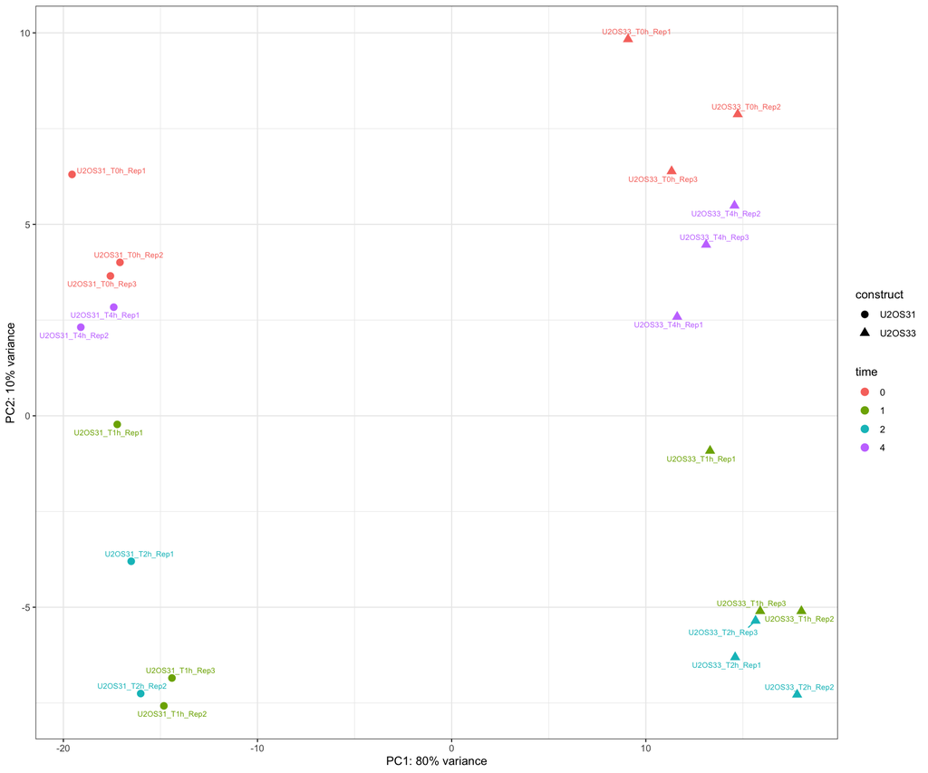

```r
> pca.H3ac <- plotPCA(rlog.H3ac,
+                     intgroup = c("construct", "time"),
+                     returnData = T)
> per.Var <- round(100 * attr(pca.H3ac, "percentVar"))
>
> ggplot(pca.H3ac, aes(PC1, PC2, color = time %>% as.factor(), shape = construct, label = name)) +
+   geom_point(size = 3) +
+   geom_text_repel(size = 2.5) +
+   labs(x = paste0("PC1: ", per.Var[1], "% variance"),
+        y = paste0("PC2: ", per.Var[2], "% variance"),
+        color = "time",
+        main = "PCA for H3K27ac after infection in hours") +
+   theme_bw()
```

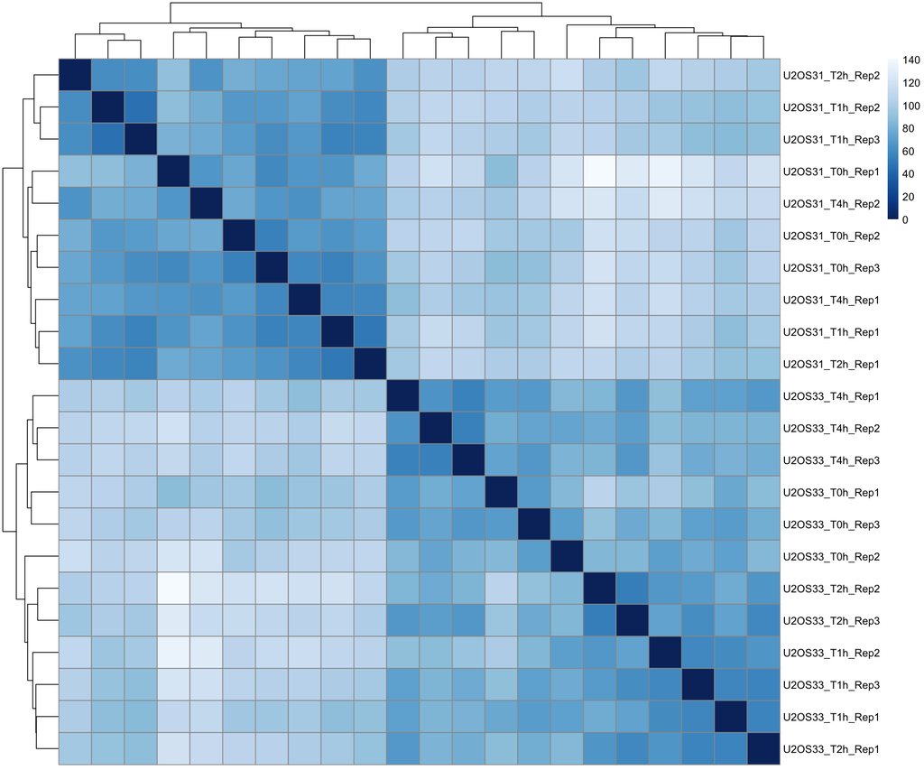

```r
> sample.dist <- dist(t(assay(rlog.H3ac)))
> m.dist <- sample.dist %>% as.matrix()
> colnames(m.dist) <- NULL
>
> col <- colorRampPalette( rev(brewer.pal(9, "Blues")) )(255)
>
> plot.heat <- pheatmap(m.dist,
+                       clustering_distance_rows = sample.dist,
+                       clustering_distance_cols = sample.dist,
+                       col = col)
```

## Significance testing (Likelihood ratio test - LRT)

To find significant peaks a likelihood ratio test (LRT) was used. This test compares 2 models, the full model (M ~ construct + replica + time) and the simpler model (M(s) ~ construct + replica). This results in peaks which show significant difference between those 2 models, in this case only peaks which significantly affect the larger model will score a low enough p-values. The output was then used to filter the rlog data for significant peaks (adjusted p value <= 0.05).

```r
> H3ac.LRT <- DESeq(H3ac.coverage, test = "LRT", reduced = ~ construct + replica)
>
> head(H3ac.LRT)
```

```
## class: DESeqDataSet
## dim: 6 22
## metadata(1): version
## assays(4): counts mu H cooks
## rownames(6): chr1:181453-181717 chr1:777858-779502 ...
##   chr1:920444-922078 chr1:923270-926516
## rowData names(27): baseMean baseVar ... deviance maxCooks
## colnames(22): U2OS31_T0h_Rep1 U2OS31_T0h_Rep2 ... U2OS33_T4h_Rep2
##   U2OS33_T4h_Rep3
## colData names(4): construct replica time sizeFactor
```

```r
> res <- results(H3ac.LRT)
>
> head(res)
```

```
## log2 fold change (MLE): time
## LRT p-value: '~ construct + replica + time' vs '~ construct + replica'
## DataFrame with 6 rows and 6 columns
##                     baseMean log2FoldChange     lfcSE      stat     pvalue
##                    <numeric>      <numeric> <numeric> <numeric>  <numeric>
## chr1:181453-181717   19.8295     -0.0274382 0.0708144  0.146171 0.70222137
## chr1:777858-779502  115.4950     -0.0931898 0.0495954  3.678751 0.05511012
## chr1:827213-827667   27.6409     -0.0240558 0.0694030  0.123165 0.72562641
## chr1:903806-905645  171.2062     -0.0775925 0.0456288  2.718311 0.09920291
## chr1:920444-922078   55.3373     -0.4053070 0.1330429  7.275346 0.00699074
## chr1:923270-926516  431.2111     -0.2907847 0.0853096  9.642893 0.00190086
##                         padj
##                    <numeric>
## chr1:181453-181717 0.8500394
## chr1:777858-779502 0.1925655
## chr1:827213-827667 0.8631848
## chr1:903806-905645 0.2764747
## chr1:920444-922078 0.0503011
## chr1:923270-926516 0.0207135
```

```r
> res.sig <- res[which(res$padj <= 0.05), ]
>
> rlog.H3ac.sig <- rlog.H3ac[rownames(res.sig), ]
>
> saveRDS(rlog.H3ac.sig, file = "./Data/rlog_H3K27ac_sig.rds")
```

## References - packages

- Ahlmann-Eltze C, Hickey P, Pagès H (2023). *MatrixGenerics: S4 Generic Summary Statistic Functions that Operate on Matrix-Like Objects*. doi:10.18129/B9.bioc.MatrixGenerics https://doi.org/10.18129/B9.bioc.MatrixGenerics, R package version 1.12.2, https://bioconductor.org/packages/MatrixGenerics.
- Allaire J, Xie Y, Dervieux C, McPherson J, Luraschi J, Ushey K, Atkins A, Wickham H, Cheng J, Chang W, Iannone R (2023). *rmarkdown: Dynamic Documents for R*. R package version 2.23, https://github.com/rstudio/rmarkdown. Xie Y, Allaire J, Grolemund G (2018). *R Markdown: The Definitive Guide*. Chapman and Hall/CRC, Boca Raton, Florida. ISBN 9781138359338, https://bookdown.org/yihui/rmarkdown. Xie Y, Dervieux C, Riederer E (2020). *R Markdown Cookbook*. Chapman and Hall/CRC, Boca Raton, Florida. ISBN 9780367563837, https://bookdown.org/yihui/rmarkdown-cookbook.
- Arora S, Morgan M, Carlson M, Pagès H (2023). *GenomeInfoDb: Utilities for manipulating chromosome names, including modifying them to follow a particular naming style*. doi:10.18129/B9.bioc.GenomeInfoDb https://doi.org/10.18129/B9.bioc.GenomeInfoDb, R package version 1.36.0, https://bioconductor.org/packages/GenomeInfoDb.
- Bengtsson H (2023). *matrixStats: Functions that Apply to Rows and Columns of Matrices (and to Vectors)*. R package version 1.0.0, https://CRAN.R-project.org/package=matrixStats.
- Huber W, Carey VJ, Gentleman R, Anders S, Carlson M, Carvalho BS, Bravo HC, Davis S, Gatto L, Girke T, Gottardo R, Hahne F, Hansen KD, Irizarry RA, Lawrence M, Love MI, MacDonald J, Obenchain V, Ole’s AK, Pag`es H, Reyes A, Shannon P, Smyth GK, Tenenbaum D, Waldron L, Morgan M (2015). “Orchestrating high-throughput genomic analysis with Bioconductor.” *Nature Methods*, *12*(2), 115-121. http://www.nature.com/nmeth/journal/v12/n2/full/nmeth.3252.html.
- Huber, W., Carey, J. V, Gentleman, R., Anders, S., Carlson, M., Carvalho, S. B, Bravo, C. H, Davis, S., Gatto, L., Girke, T., Gottardo, R., Hahne, F., Hansen, D. K, Irizarry, A. R, Lawrence, M., Love, I. M, MacDonald, J., Obenchain, V., Ole’s, K. A, Pag`es, H., Reyes, A., Shannon, P., Smyth, K. G, Tenenbaum, D., Waldron, L., Morgan, M. (2015). “Orchestrating high-throughput genomic analysis with Bioconductor.” *Nature Methods*, *12*(2), 115-121. http://www.nature.com/nmeth/journal/v12/n2/full/nmeth.3252.html.
- Kolde R (2019). *pheatmap: Pretty Heatmaps*. R package version 1.0.12, https://CRAN.R-project.org/package=pheatmap.
- Lawrence M, Huber W, Pagès H, Aboyoun P, Carlson M, Gentleman R, Morgan M, Carey V (2013). “Software for Computing and Annotating Genomic Ranges.” *PLoS Computational Biology*, *9*. doi:10.1371/journal.pcbi.1003118 https://doi.org/10.1371/journal.pcbi.1003118, http://www.ploscompbiol.org/article/info%3Adoi%2F10.1371%2Fjournal.pcbi.1003118.
- Lawrence M, Huber W, Pagès H, Aboyoun P, Carlson M, Gentleman R, Morgan M, Carey V (2013). “Software for Computing and Annotating Genomic Ranges.” *PLoS Computational Biology*, *9*. doi:10.1371/journal.pcbi.1003118 https://doi.org/10.1371/journal.pcbi.1003118, http://www.ploscompbiol.org/article/info%3Adoi%2F10.1371%2Fjournal.pcbi.1003118.
- Love MI, Huber W, Anders S (2014). “Moderated estimation of fold change and dispersion for RNA-seq data with DESeq2.” *Genome Biology*, *15*, 550. doi:10.1186/s13059-014-0550-8 https://doi.org/10.1186/s13059-014-0550-8.
- Makowski D, Lüdecke D, Patil I, Thériault R, Ben-Shachar M, Wiernik B (2023). “Automated Results Reporting as a Practical Tool to Improve Reproducibility and Methodological Best Practices Adoption.” *CRAN*. https://easystats.github.io/report/.
- Morgan M, Obenchain V, Hester J, Pagès H (2023). *SummarizedExperiment: SummarizedExperiment container*. doi:10.18129/B9.bioc.SummarizedExperiment https://doi.org/10.18129/B9.bioc.SummarizedExperiment, R package version 1.30.2, https://bioconductor.org/packages/SummarizedExperiment.
- Neuwirth E (2022). *RColorBrewer: ColorBrewer Palettes*. R package version 1.1-3, https://CRAN.R-project.org/package=RColorBrewer.
- Pagès H, Lawrence M, Aboyoun P (2023). *S4Vectors: Foundation of vector-like and list-like containers in Bioconductor*. doi:10.18129/B9.bioc.S4Vectors https://doi.org/10.18129/B9.bioc.S4Vectors, R package version 0.38.1, https://bioconductor.org/packages/S4Vectors.
- R Core Team (2023). *R: A Language and Environment for Statistical Computing*. R Foundation for Statistical Computing, Vienna, Austria. https://www.R-project.org/.
- Slowikowski K (2023). *ggrepel: Automatically Position Non-Overlapping Text Labels with ‘ggplot2’*. R package version 0.9.3, https://CRAN.R-project.org/package=ggrepel.
- Wickham H (2016). *ggplot2: Elegant Graphics for Data Analysis*. Springer-Verlag New York. ISBN 978-3-319-24277-4, https://ggplot2.tidyverse.org.
- Wickham H (2022). *stringr: Simple, Consistent Wrappers for Common String Operations*. R package version 1.5.0, https://CRAN.R-project.org/package=stringr.
- Wickham H, François R, Henry L, Müller K, Vaughan D (2023). *dplyr: A Grammar of Data Manipulation*. R package version 1.1.2, https://CRAN.R-project.org/package=dplyr.
- Xie Y (2023). *knitr: A General-Purpose Package for Dynamic Report Generation in R*. R package version 1.43, https://yihui.org/knitr/. Xie Y (2015). *Dynamic Documents with R and knitr*, 2nd edition. Chapman and Hall/CRC, Boca Raton, Florida. ISBN 978-1498716963, https://yihui.org/knitr/. Xie Y (2014). “knitr: A Comprehensive Tool for Reproducible Research in R.” In Stodden V, Leisch F, Peng RD (eds.), *Implementing Reproducible Computational Research*. Chapman and Hall/CRC. ISBN 978-1466561595.